# Taller EDA

Josué Redondo Gómez

2025-12-04

# 3. Configuración del Entorno de Trabajo

## 3.3 Importar el dataset

### • Actividad: Anotar cuántas filas y columnas tiene el dataset

```
## El dataset tiene  2000  filas y 7 columnas
```

# 4. Exploración inicial del Dataset

## 4.1 Ver las primeras 6 filas:

```
##   Student_ID Attendance.... Internal.Test.1..out.of.40.
## 1      S1000             84                          30
## 2      S1001             91                          24
## 3      S1002             73                          29
## 4      S1003             80                          36
## 5      S1004             84                          31
## 6      S1005            100                          34
##   Internal.Test.2..out.of.40. Assignment.Score..out.of.10. Daily.Study.Hours
## 1                          36                            7                 3
## 2                          38                            6                 3
## 3                          26                            7                 3
## 4                          35                            7                 3
## 5                          37                            8                 3
## 6                          34                            7                 3
##   Final.Exam.Marks..out.of.100.
## 1                            72
## 2                            56
## 3                            56
## 4                            74
## 5                            66
## 6                            79
```

## 4.1 Ver las últimas 6 filas:

```
##      Student_ID Attendance.... Internal.Test.1..out.of.40.
## 1995      S2994             97                          40
## 1996      S2995             82                          31
## 1997      S2996             78                          38
## 1998      S2997             78                          30
## 1999      S2998             82                          29
## 2000      S2999             97                          32
##      Internal.Test.2..out.of.40. Assignment.Score..out.of.10. Daily.Study.Hours
## 1995                          38                            9                 4
## 1996                          28                            6                 2
## 1997                          27                            7                 2
## 1998                          33                            9                 2
## 1999                          40                            8                 3
## 2000                          38                            7                 3
##      Final.Exam.Marks..out.of.100.
## 1995                            81
## 1996                            52
## 1997                            57
## 1998                            61
## 1999                            59
## 2000                            64
```

## 4.2 Estructura del dataset

```
## 'data.frame':    2000 obs. of  7 variables:
##  $ Student_ID                   : chr  "S1000" "S1001" "S1002" "S1003" ...
##  $ Attendance....               : int  84 91 73 80 84 100 96 83 91 87 ...
##  $ Internal.Test.1..out.of.40.  : int  30 24 29 36 31 34 40 39 30 27 ...
##  $ Internal.Test.2..out.of.40.  : int  36 38 26 35 37 34 36 37 37 37 ...
##  $ Assignment.Score..out.of.10. : int  7 6 7 7 8 7 8 7 8 8 ...
##  $ Daily.Study.Hours            : int  3 3 3 3 3 3 3 3 2 3 ...
##  $ Final.Exam.Marks..out.of.100.: int  72 56 56 74 66 79 83 77 71 61 ...
```

### • Actividad: Ejecutar el código str(datos) y responder: 1. ¿Cuántas variables numéricas existen? 2. ¿Existe alguna variable de tipo texto (character)?

#### 1. Existen 6 variables numéricas.

#### 2. Solo existe una variable de tipo texto.

## 4.3 Resumen estadístico rápido

```
##   Student_ID        Attendance....   Internal.Test.1..out.of.40.
##  Length:2000        Min.   : 52.00   Min.   :18.00
##  Class :character   1st Qu.: 80.00   1st Qu.:29.00
##  Mode  :character   Median : 85.00   Median :32.00
##                     Mean   : 84.89   Mean   :32.12
##                     3rd Qu.: 90.00   3rd Qu.:35.00
##                     Max.   :100.00   Max.   :40.00
##  Internal.Test.2..out.of.40. Assignment.Score..out.of.10. Daily.Study.Hours
##  Min.   :16.00               Min.   : 4.000               Min.   :1.000
##  1st Qu.:29.00               1st Qu.: 7.000               1st Qu.:2.000
##  Median :33.00               Median : 8.000               Median :3.000
##  Mean   :32.46               Mean   : 7.507               Mean   :2.824
##  3rd Qu.:36.00               3rd Qu.: 8.000               3rd Qu.:3.000
##  Max.   :40.00               Max.   :10.000               Max.   :5.000
##  Final.Exam.Marks..out.of.100.
##  Min.   : 25.00
##  1st Qu.: 58.00
##  Median : 65.00
##  Mean   : 64.86
##  3rd Qu.: 73.00
##  Max.   :100.00
```

### • Actividad: Con el resultado de summary(datos), se deben anotar los valores de Mínimo, Máximo, Mediana y Media para la variable Final Exam Mark:

### Resumen Estadístico Rápido de Final_Exam_Mark

#### Mínimo: 25.00

#### Máximo: 100.00

#### Mediana: 65.00

#### Media: 64.86

# 5. Limpieza y Preparación de Datos

## 5.2 Verificar Valores Faltantes

```
##               ID       Asistencia Examen_Interno_1 Examen_Interno_2
##                0                0                0                0
##  Promedio_Tareas    Horas_Estudio       Nota_Final
##                0                0                0
```

```
## Total de Valores Faltantes:  0
```

### • Actividad: ¿Existen valores faltantes en el dataset? ¿En cuáles variables?

#### No existen valores faltantes en ninguna variable.

# 6. Estadística Descriptiva: Nota del Examen Final

### • Actividad: Se deben calcular las medidas de tendencia central para Nota Final y anotar los resultados

## 6.1 Medidas de Tendencia Central

```
##  Media : 64.86
```

```
##  Mediana : 65
```

```
##  Moda : 66
```

### • Actividad: Se deben calcular las medidas de dispersión para Nota Final:

## 6.2 Medidas de Dispersión para Nota_Final

### Varianza

```
## Varianza:  128.62
```

### Desviación Estándar

```
##  Desviacion Estandar : 11.34
```

### Cuartiles

```
## Q1 (25%) : 58
```

```
## Q2 (50%) : 65
```

```
## Q3 (75%) : 73
```

### Rango

```
##  Rango : 75
```

# 7. Visualización de Datos

## 7.1 Gráfico de Pastel: Categorías de Rendimiento

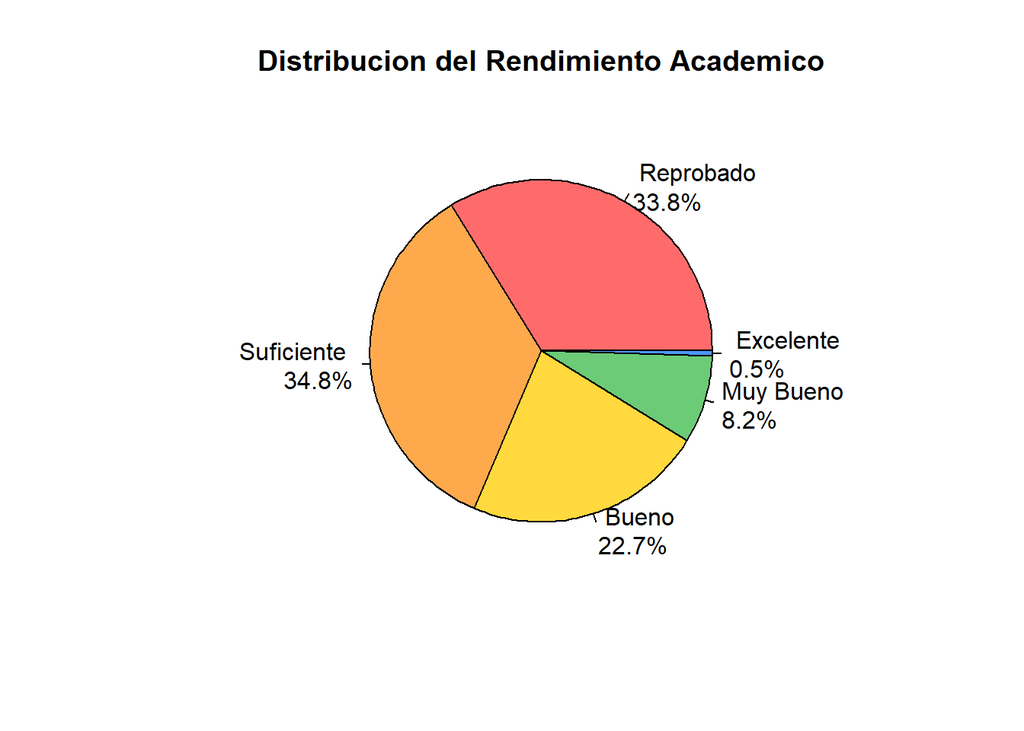

### • Actividad: Se debe observar el gráfico de pastel y responder: 1. ¿Cuál es la categoría con más estudiantes? 2. ¿Qué porcentaje de estudiantes reprobó?

#### 1. La categoría con más estudiantes es “Suficiente”

#### 2. Reprobó un 33.8% de los estudiantes

## 7.2 Diagrama de Barras Horizontales: Nivel de Asistencia

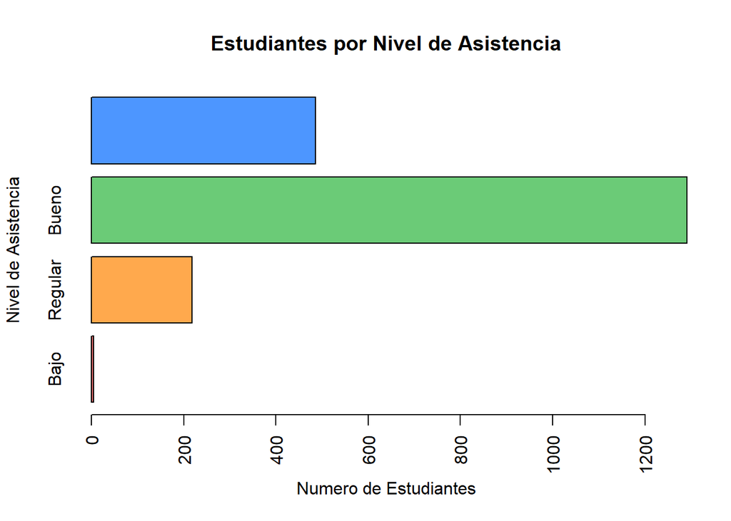

### • Actividad: Se debe observar el gráfico de barras y responder: 1. ¿Cuántos estudiantes tienen asistencia “Excelente”? 2. ¿Cuál nivel de asistencia tiene menos estudiantes?

#### 1. Hay 500 estudiantes que tienen una asistencia “Excelente”

#### 2. El nivel de asistencia “Bajo” es el que tienen menos estudiantes

## 7.3 Diagrama de Cajas: Exámenes Internos 1 y 2

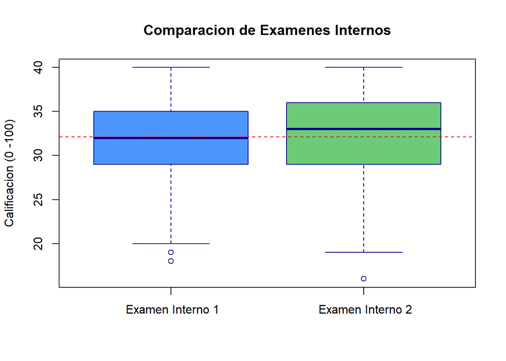

```
## === EXAMEN INTERNO 1 === n
```

```
##  Media : 32.12
```

```
##  Mediana : 32
```

```
##  Desv . Est .: 4.56
```

```
## === EXAMEN INTERNO 2 === n
```

```
##  Media : 32.46
```

```
##  Mediana : 33
```

```
##  Desv . Est .: 4.52
```

### • Actividad:Se deben comparar los dos exámenes internos usando el boxplot y las estadísticas: 1. ¿Cuál examen tiene la mediana más alta? 2. ¿Cuál examen tiene mayor dispersión (desviación estándar)? 3. ¿Se observan valores atípicos en alguno de los exámenes?

#### 1. El Examen Interno 2 tiene una mediana más alta (33)

#### 2. El Examen Interno 1 tiene una mayor Desviación Estándar (4.56)

#### 3. En el Examen Interno 1 hay dos valores atípicos, mientras que en el Examen Interno 2 hay solo un valor atípico

## 7.4 Gráfico de Violín: Nota Final por Nivel de Asistencia

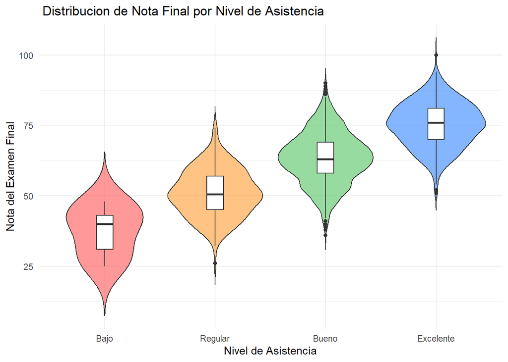

### • Actividad: Se debe observar el gráfico de violín y responder: 1. ¿Cuál nivel de asistencia muestra las notas más altas? 2. ¿Se observa alguna diferencia en la forma de las distribuciones?

#### 1. El nivel de Asistencia “Excelente” tiene las notas más altas.

#### 2. Si se observa una diferencia en la forma de las distribuciones

# 8. Análisis de Normalidad: Nota del Examen Final

## 8.1 Histograma de la Nota Final

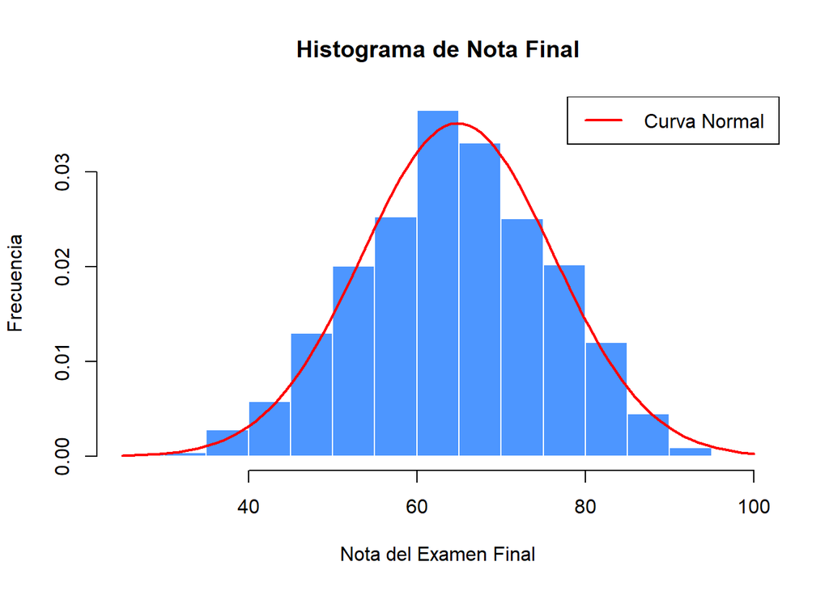

### • Actividad: Se debe observar el histograma y responder: 1. ¿El histograma tiene forma de campana? 2. ¿La distribuci´on parece simétrica o sesgada?

#### 1. El histograma SI tiene forma de Campana

#### 2. La distribución parece ser Simétrica

## 8.2 Gráfico Q-Q (Quantile-Quantile)

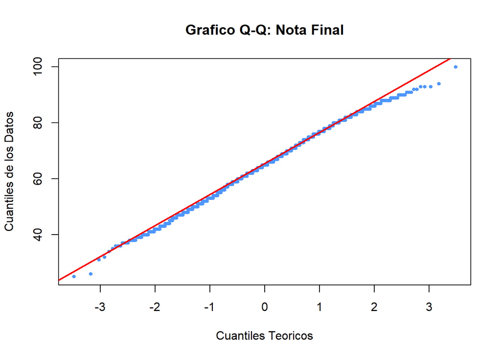

### • Actividad: Se debe observar el gráfico Q-Q y describir lo observado:

#### La gran mayoría de los puntos siguen a la línea roja.

#### Si existen desviaciones en los extremos, principalmente en el extremo superior.

## 8.3 Pruebas Estadísticas de Normalidad

### Prueba de Shapiro-Wilk

```
## === PRUEBA DE SHAPIRO - WILK === n
```

```
##  Estadistico W: 0.9966
```

```
##  Valor p: 0.0002190907
```

```
##  Conclusion : Los datos NO SON NORMALES (p <= 0.05)
```

### Prueba de Kolmogorov-Smirnov

```
## === PRUEBA DE KOLMOGOROV - SMIRNOV === n
```

```
##  Estadistico D: 0.029
```

```
##  Valor p: 0.06953239
```

```
##  Conclusion : Los datos SON NORMALES (p > 0.05)
```

### • Actividad: Se deben ejecutar las pruebas de normalidad y completar:

### Prueba de Shapiro - Wilk

#### Valor p = 0.0002190907, Conclusión: Los datos NO son normales

### Prueba de Kolmogorov - Smirnov

#### Valor p = 0.06953239, Conclusión: Los datos son normales

#### Los datos de Nota_Final NO son normales según la prueba Shapiro - Wilk, pero según la prueba de Kolmogorov - Smirnov si son normales.

# 9. Visualizaciones Avanzadas

## 9.1 Mapa de Calor (Heatmap) de Correlaciones

### Matriz de Correlación

```
##                  Asistencia Examen_Interno_1 Examen_Interno_2 Promedio_Tareas
## Asistencia             1.00             0.51             0.49            0.43
## Examen_Interno_1       0.51             1.00             0.26            0.57
## Examen_Interno_2       0.49             0.26             1.00            0.54
## Promedio_Tareas        0.43             0.57             0.54            1.00
## Horas_Estudio          0.30             0.21             0.23            0.17
## Nota_Final             0.73             0.69             0.69            0.67
##                  Horas_Estudio Nota_Final
## Asistencia                0.30       0.73
## Examen_Interno_1          0.21       0.69
## Examen_Interno_2          0.23       0.69
## Promedio_Tareas           0.17       0.67
## Horas_Estudio             1.00       0.41
## Nota_Final                0.41       1.00
```

### Mapa de Calor Básico

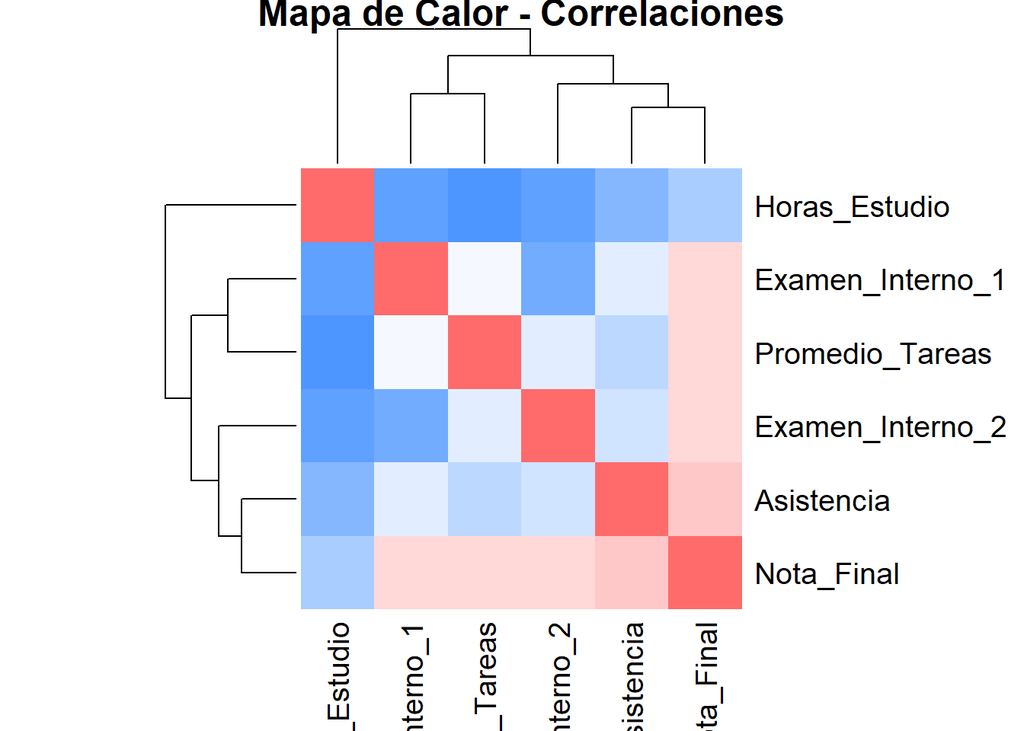

### Mapa de Calor Mejorado

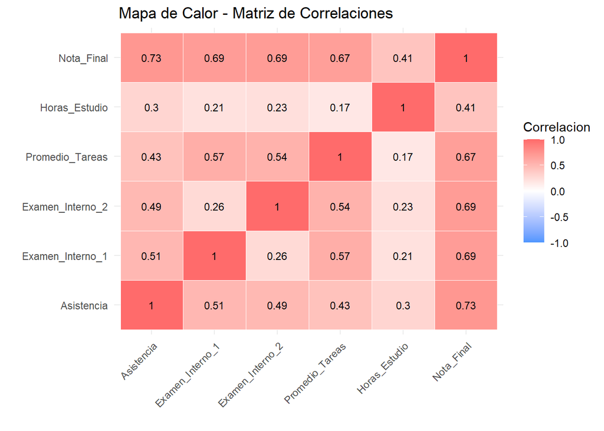

### • Actividad: Se debe observar el mapa de calor y responder: 1. ¿Cuáles dos variables tienen la correlación más fuerte (más cercana a 1)? 2. ¿Existe alguna correlación negativa entre las variables? 3. ¿Cuál variable tiene la mayor correlación con Nota Final?

#### 1. Las variables que tienen una correlación más fuerte son “Asistencia” y “Nota Final” con un valor de 0.73

#### 2. No existe ninguna correlación negativa entre las variables

#### 3. La variable que tiene mayor correlación con “Nota_Final” es “Asistencia”

## 9.2 Gráfico de Violín: Nota Final por Nivel de Asistencia

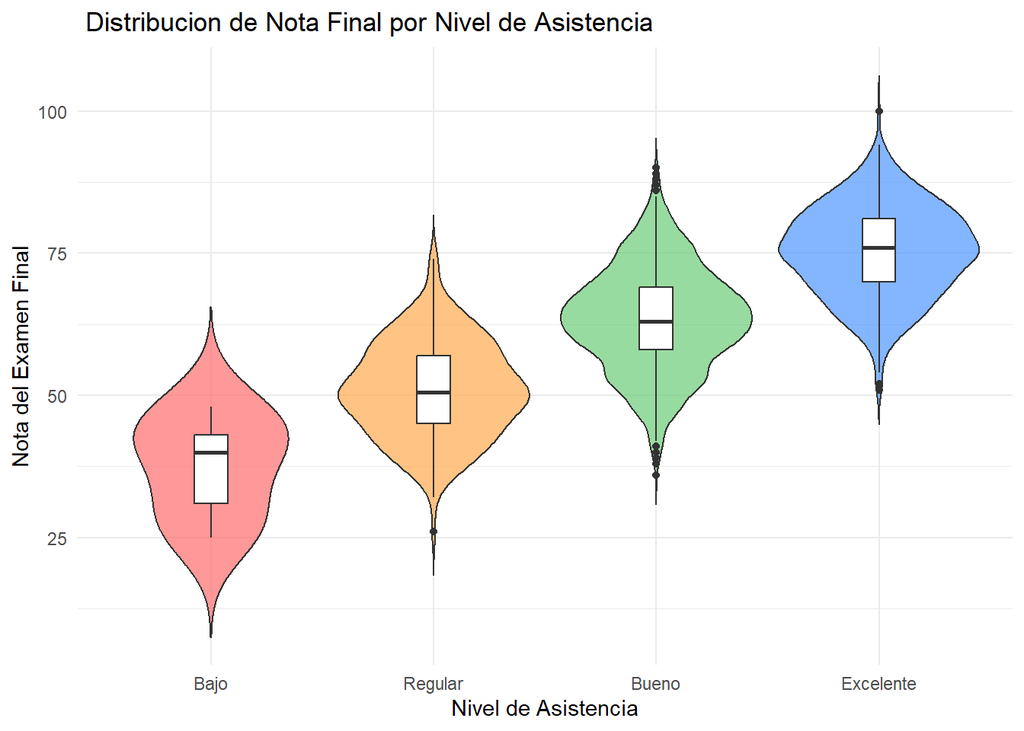

### • Actividad: Se debe observar el gráfico de violín de Nota Final por Nivel de Asistencia y responder: 1. ¿Cuál nivel de asistencia muestra la distribución más concentrada (violín más angosto)? 2. ¿En cuál nivel de asistencia se observan las notas más altas? 3. ¿Qué se puede concluir sobre la relación entre asistencia y rendimiento?

#### 2. Las notas más altas se encuentran en el nivel de asistencia “Excelente”

#### 3. De la relación entre “Asistencia” y “Rendimiento” se puede concluir que entre mayor es la “Asistencia”, mejor es el “Rendimiento”.

# 10. Análisis de Correlación

## 10.1 Mapa de Calor (Heatmap) de Correlaciones

### Calcular matriz de correlación

```
##                  Asistencia Examen_Interno_1 Examen_Interno_2 Promedio_Tareas
## Asistencia             1.00             0.51             0.49            0.43
## Examen_Interno_1       0.51             1.00             0.26            0.57
## Examen_Interno_2       0.49             0.26             1.00            0.54
## Promedio_Tareas        0.43             0.57             0.54            1.00
## Horas_Estudio          0.30             0.21             0.23            0.17
## Nota_Final             0.73             0.69             0.69            0.67
##                  Horas_Estudio Nota_Final
## Asistencia                0.30       0.73
## Examen_Interno_1          0.21       0.69
## Examen_Interno_2          0.23       0.69
## Promedio_Tareas           0.17       0.67
## Horas_Estudio             1.00       0.41
## Nota_Final                0.41       1.00
```

### Crear mapa de calor con corrplot

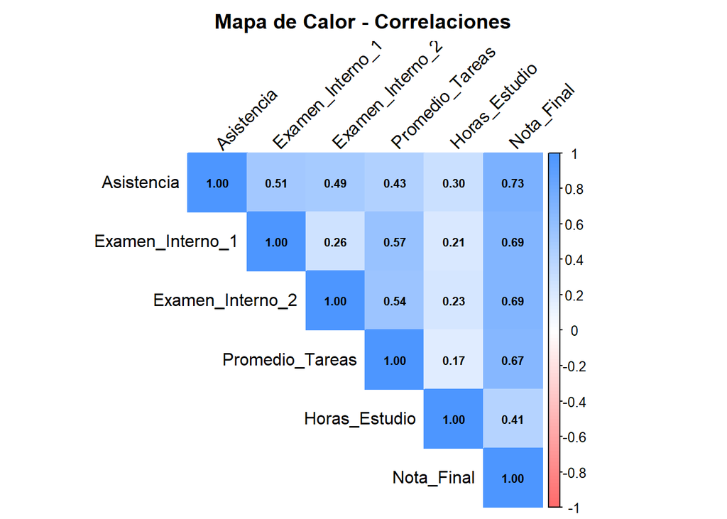

### Mapa de calor alternativo con ggplot2

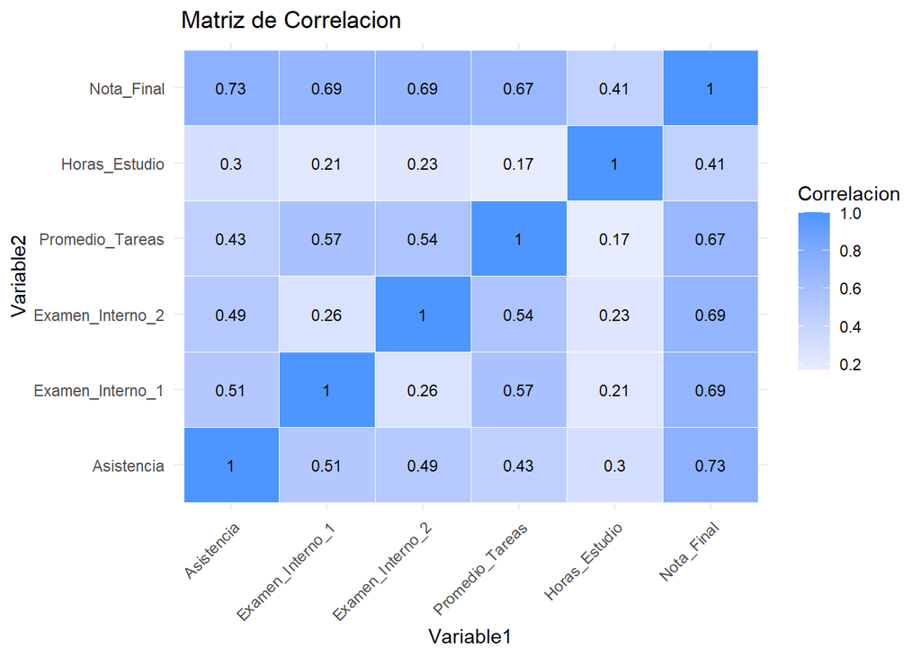

### • Actividad: Se debe observar el mapa de calor y responder: 1. ¿Cuáles dos variables tienen la correlación más alta? 2. ¿Existe alguna correlación negativa? 3. ¿Qué variable tiene la correlación más fuerte con Nota Final?

#### 1. La correlación más alta la tienen las variables “Nota Final” y “Asistencia”

#### 2. No existe ninguna relación negativa

#### 3. La variable “Asistencia” tiene la correlación más fuerte con la variable “Nota Final”

## 10.2 Gráfico de Dispersión: Asistencia vs Nota Final

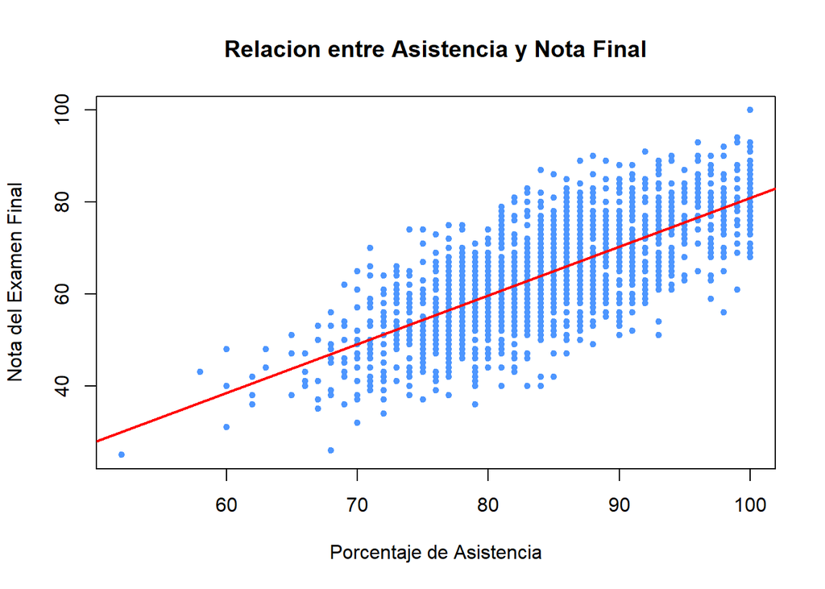

### • Actividad: Se debe calcular la correlación entre Asistencia y Nota Final:

## 10.3 Cálculo del Coeficiente de Correlación

```
##  Coeficiente de correlacion (r): 0.7256
```

```
##  Valor p: 0
```

```
## [1] "Es una correlación fuerte"
```

```
## La correlacion ES estadisticamente significativa
```

# 11. Regresión Lineal Simple

### • Actividad: Se debe crear el modelo de regresión y completar:

## 11.1 Crear el Modelo de Regresión

```
##
## Call:
## lm(formula = Nota_Final ~ Asistencia, data = datos)
##
## Residuals:
##      Min       1Q   Median       3Q      Max
## -23.9094  -5.4021   0.1196   5.4230  23.0906
##
## Coefficients:
##             Estimate Std. Error t value Pr(>|t|)
## (Intercept) -25.1883     1.9181  -13.13   <2e-16 ***
## Asistencia    1.0607     0.0225   47.14   <2e-16 ***
## ---
## Signif. codes:  0 '***' 0.001 '**' 0.01 '*' 0.05 '.' 0.1 ' ' 1
##
## Residual standard error: 7.806 on 1998 degrees of freedom
## Multiple R-squared:  0.5266, Adjusted R-squared:  0.5263
## F-statistic:  2222 on 1 and 1998 DF,  p-value: < 2.2e-16
```

## 11.2 Interpretar los Resultados

```
## === ECUACION DEL MODELO === n
```

```
##  Nota_Final = -25.19 + 1.06 * Asistencia
```

```
## R cuadrado (R^2): 0.5266
```

```
##  Esto significa que la Asistencia explica el 52.7 % de la variabilidad en la Nota
## Final
```

## 11.3 Visualizar el Modelo de Regresión

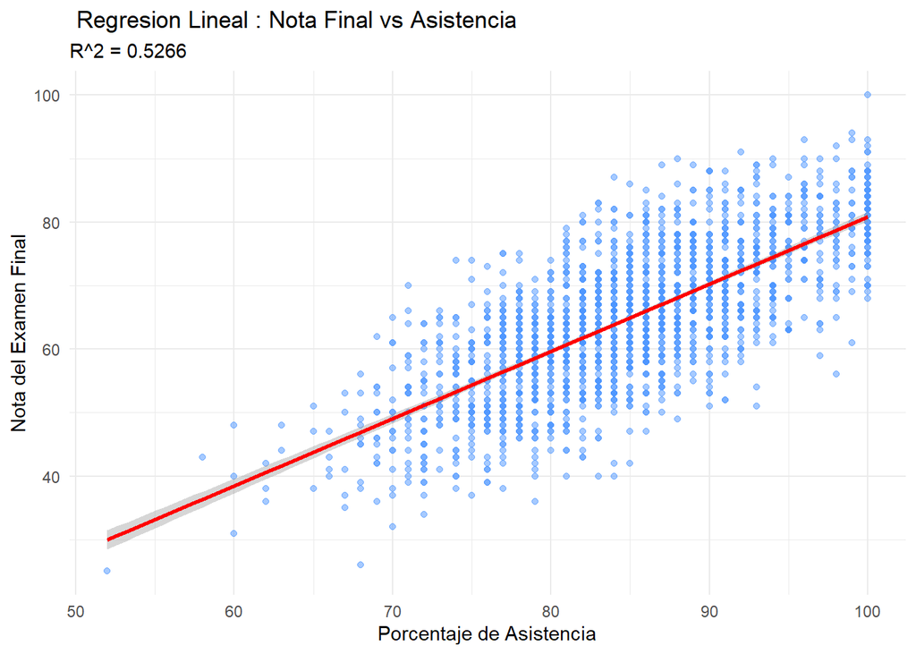

## 11.4 Realizar Predicciones

```
## === PREDICCIONES === n
```

```
## Si la asistencia es 60 % -> Nota predicha : 38.5
## Si la asistencia es 70 % -> Nota predicha : 49.1
## Si la asistencia es 80 % -> Nota predicha : 59.7
## Si la asistencia es 90 % -> Nota predicha : 70.3
## Si la asistencia es 100 % -> Nota predicha : 80.9
```

### • Actividad: Se debe usar el modelo para predecir la nota de un estudiante que tiene 85% de asistencia:

```
##  Nota predicha para 85% de asistencia : 65
```

# 12 Actividades de Cierre

### • Actividad: Con base en todo el análisis realizado, se deben responder las siguientes preguntas:

### Pregunta 1: ¿Cuál es el promedio de la Nota Final de todos los estudiantes?

```
## El promedio de la Nota Final de todos los estudiantes es: 64.86
```

### Pregunta 2: ¿Los datos de Nota Final siguen una distribución normal? Justificar la respuesta.

Los datos de Nota Final NO siguen una distribución perfectamente normal. Si bien es cierto se puede decir que los datos SON normales debido a que el histograma si tiene forma de campana, en el gráfico Q-Q la gran mayoría de los puntos sigue la línea (mostrando desviaciones en los extremos) y la prueba de Kolmogorov-Smirnov tuvo un valor mayor a 0.05. No obstante, la prueba de Shapiro-Wilk indica que p = 0.000219 (< 0.05), lo cual muestra que los datos NO son normales.

En conclusión, los datos de Nota Final muestran una normalidad aproximada con ligeras desviaciones. No cumple estrictamente con el supuesto de normalidad según la prueba de Shapiro-Wilk.

### Pregunta 3: ¿Existe una relación significativa entre la Asistencia y la Nota Final?

```
## === ANÁLISIS DE CORRELACIÓN ===
```

```
## Coeficiente de correlación (r): 0.7256
```

```
## Valor p: 0
```

```
## === INTERPRETACIÓN ===
```

```
## Magnitud de la correlación: FUERTE
```

```
## Significancia estadística: SÍ (p < 0.05)
```

SÍ existe una relación significativa entre la Asistencia y la Nota Final.

### Pregunta 4: Según el modelo, ¿cuánto aumenta la nota final por cada punto porcentual adicional de asistencia?

```
## === ECUACIÓN DEL MODELO DE REGRESIÓN ===
```

```
## Nota_Final = -25.19 + 1.06 × Asistencia
```

```
## === INTERPRETACIÓN DE LA PENDIENTE ===
```

```
## Por cada 1% adicional de asistencia, la Nota Final aumenta: 1.06 puntos
```

```
## === EJEMPLOS PRÁCTICOS ===
```

```
## • Si un estudiante aumenta su asistencia de 70% a 71% (+1%):
```

```
##   Aumento esperado en nota: 1.06 puntos
```

```
## • Si un estudiante aumenta su asistencia de 70% a 80% (+10%):
```

```
##   Aumento esperado en nota: 10.61 puntos
```

```
## • Si un estudiante aumenta su asistencia de 60% a 90% (+30%):
```

```
##   Aumento esperado en nota: 31.82 puntos
```

### Pregunta 5: ¿Qué recomendaciones se le darían a un estudiante que desea mejorar su nota final?

Para mejorar su nota final, yo le recomendaría al estudiante que mejore su asistencia, dado que a lo largo del taller se ha evidenciado la estrecha correlación entre la Nota Final y la Asistencia, además este es el factor más controlable por el estudiante. Complementar esto con esfuerzo en tareas y estudio consistente maximizará los resultados.